# B4BI Pak Choi Seed Data Graphs and Models for paper

Heather Jenkins

19 October 2026

# Overview

This document contains the final analysis and graphs of the pak choi seed data.

This analysis was performed using R version 4.6.1 (2026-06-24 ucrt). The *tidyverse* suite of packages was used for data manipulation and visualisation. The *emmeans* package was used for model predictions. The *DHARMa* package was used to help assess model diagnostics and goodness-of-fit.

The predicted 95% confidence intervals and post-hoc pairwise comparison p-values are adjusted using the FDR correction to account for multiple tests.

# Data used (how it was summarised)

- The original data is grouped by Year, Farm, Type_of_farm, Boundary_type, Native_new_age, Treatment, Rep.
- The mean of the `Seed viable` is taken. This is the mean across all the pods for each rep. Note the number of pods for each Rep was quite variable.
- Then the data is grouped by Year, Farm, Type_of_farm, Boundary_type, Native_new_age, Treatment.
- The mean seeds viable is calculated, so we get a mean over the Reps.
- For each Year, Farm and Boundary_type combination we have a mean seed count for each treatment where each rep has the same weight in the mean.
- If we didn’t do the means with the two group_by steps then each pod would have the same weight in the mean.
- I’ve assumed that the number of pods is a feature of the pak choi plants and nothing to do with the Treatments.

```
## tibble [319 × 9] (S3: tbl_df/tbl/data.frame)
##  $ Year                     : Factor w/ 3 levels "Year 2021-22",..: 1 1 1 1 1 1 1 1 ...
##  $ Farm                     : Factor w/ 19 levels "Ahuriri","Ashford 1",..: 1 1 1 1 1 2 2 2 ...
##  $ Type_of_farm             : Factor w/ 2 levels "Cropping","Dairy": 1 1 1 1 1 2 2 2 ...
##  $ Boundary_type            : Factor w/ 4 levels "Control farm",..: 3 3 3 1 1 3 3 3 ...
##  $ Native_new_age           : Factor w/ 6 levels "Control farm",..: 3 3 3 1 1 3 3 3 ...
##  $ Treatment                : Factor w/ 3 levels "HP","Open","Closed": 1 2 3 1 2 1 2 3 ...
##  $ Mean_seeds_viable        : num [1:319] 16.2 14.8 1 16.2 ...
##  $ Site                     : Factor w/ 46 levels "Ahuriri:Control farm",..: 2 2 2 1 1 4 4 4 ...
##  $ Mean_seeds_viable_rounded: num [1:319] 16 15 1 16 10 17 10 0 ...
```

We next remove the data with ‘one-year old new SNH’ and ‘two-year old new SNH’ in 2023-24 is removed. So ‘New native’ only has

- One year old in 2021-22
- Two year old in 2022-23
- Three year old in 2023-24

Note that is data is all from Arable/Cropping farms (Garrickfield and Limbrick), and there are only 4 observations removed.

Tables of counts before and after the observations are removed are below:

|  | Control farm | Bare fence | One-year old new SNH | Two-year old new SNH | Three-year old new SNH | Old SNH |
| --- | --- | --- | --- | --- | --- | --- |
| Year 2021-22 | 23 | 32 | 18 | 0 | 0 | 36 |
| Year 2022-23 | 24 | 33 | 0 | 21 | 0 | 36 |
| Year 2023-24 | 23 | 21 | 2 | 2 | 20 | 28 |

|  | Control farm | Bare fence | One-year old new SNH | Two-year old new SNH | Three-year old new SNH | Old SNH |
| --- | --- | --- | --- | --- | --- | --- |
| Year 2021-22 | 23 | 32 | 18 | 0 | 0 | 36 |
| Year 2022-23 | 24 | 33 | 0 | 21 | 0 | 36 |
| Year 2023-24 | 23 | 21 | 0 | 0 | 20 | 28 |

```
## tibble [315 × 9] (S3: tbl_df/tbl/data.frame)
##  $ Year                     : Factor w/ 3 levels "Year 2021-22",..: 1 1 1 1 1 1 1 1 ...
##  $ Farm                     : Factor w/ 19 levels "Ahuriri","Ashford 1",..: 1 1 1 1 1 2 2 2 ...
##  $ Type_of_farm             : Factor w/ 2 levels "Cropping","Dairy": 1 1 1 1 1 2 2 2 ...
##  $ Boundary_type            : Factor w/ 4 levels "Control farm",..: 3 3 3 1 1 3 3 3 ...
##  $ Native_new_age           : Factor w/ 6 levels "Control farm",..: 3 3 3 1 1 3 3 3 ...
##  $ Treatment                : Factor w/ 3 levels "HP","Open","Closed": 1 2 3 1 2 1 2 3 ...
##  $ Mean_seeds_viable        : num [1:315] 16.2 14.8 1 16.2 ...
##  $ Site                     : Factor w/ 44 levels "Ahuriri:Control farm",..: 2 2 2 1 1 4 4 4 ...
##  $ Mean_seeds_viable_rounded: num [1:315] 16 15 1 16 10 17 10 0 ...
```

# Graphs of data

[figure not shown]

# Modelling comments

- We remove the Closed treatment from the data.
- There is no data for Arable/Cropping farms, Off-farm bare fence, 2021-22, Closed.
- The Closed is a control and we can see it “worked” in the graph above.

# Model (LMM with 4-way interaction: Y x T_F x T x B_T)

## Description

We fit linear mixed-effects models to the data. The response is Mean_seeds_viable. The fixed-effects are Year, Type_of_farm, Treatment and Boundary_type plus their four-way interaction. There is also a random effect for Farm. The residuals were inspected visually and the simulateResiduals() function from the DHARMa package was used. There was no evidence of non-normality, dispersion or outliers.

Note that a Poisson or negative-binomial model did not fit the data well.

## Diagnostics and ANOVA table

[figure not shown]

|  | Chisq | Df | Pr(>Chisq) |
| --- | --- | --- | --- |
| Type_of_farm | 0.037520 | 1 | 0.846411 |
| Treatment | 112.105177 | 1 | 0.000000 |
| Boundary_type | 37.930801 | 3 | 0.000000 |
| Year | 106.355336 | 2 | 0.000000 |
| Type_of_farm:Treatment | 0.071546 | 1 | 0.789098 |
| Type_of_farm:Boundary_type | 5.182753 | 3 | 0.158894 |
| Treatment:Boundary_type | 34.589722 | 3 | 0.000000 |
| Type_of_farm:Year | 0.780983 | 2 | 0.676724 |
| Treatment:Year | 2.647852 | 2 | 0.266089 |
| Boundary_type:Year | 9.009835 | 6 | 0.173026 |
| Type_of_farm:Treatment:Boundary_type | 1.122879 | 3 | 0.771554 |
| Type_of_farm:Treatment:Year | 0.978530 | 2 | 0.613077 |
| Type_of_farm:Boundary_type:Year | 2.894052 | 6 | 0.822022 |
| Treatment:Boundary_type:Year | 9.165754 | 6 | 0.164469 |
| Type_of_farm:Treatment:Boundary_type:Year | 0.731293 | 6 | 0.993791 |

The Kolmogorov–Smirnov test is not a big deal when there are 214 observations. The residuals look fine.

The four-way and all three-way interactions are not significant. Type_of_farm is not significant in any of the interactions or as a main effect. Year is only significant as a main effect. The two-way interaction of Treatment and Boundary_type is significant. The other two-way interactions are not significant.

## Predictions of significant effects

### Boundary_type x Treatment by Year

[figure not shown]

### Boundary_type x Treatment two-way interaction

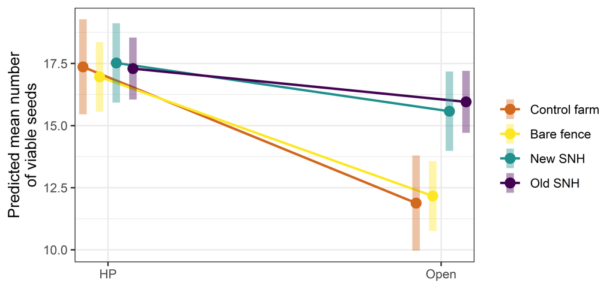

| contrast | Treatment | estimate | t.ratio | p.value |
| --- | --- | --- | --- | --- |
| Control farm - Bare fence | HP | 0.402 | 0.473 | 0.933 |
| Control farm - New SNH | HP | -0.157 | -0.177 | 0.933 |
| Control farm - Old SNH | HP | 0.069 | 0.084 | 0.933 |
| Bare fence - New SNH | HP | -0.559 | -0.739 | 0.933 |
| Bare fence - Old SNH | HP | -0.333 | -0.498 | 0.933 |
| New SNH - Old SNH | HP | 0.226 | 0.314 | 0.933 |
| Control farm - Bare fence | Open | -0.285 | -0.335 | 0.738 |
| Control farm - New SNH | Open | -3.697 | -4.158 | 0.000 |
| Control farm - Old SNH | Open | -4.074 | -4.988 | 0.000 |
| Bare fence - New SNH | Open | -3.413 | -4.512 | 0.000 |
| Bare fence - Old SNH | Open | -3.789 | -5.659 | 0.000 |
| New SNH - Old SNH | Open | -0.377 | -0.524 | 0.723 |

| contrast | Boundary_type | estimate | t.ratio | p.value |
| --- | --- | --- | --- | --- |
| HP - Open | Control farm | 5.482 | 6.226 | 0.000 |
| HP - Open | Bare fence | 4.795 | 7.458 | 0.000 |
| HP - Open | New SNH | 1.942 | 2.719 | 0.007 |
| HP - Open | Old SNH | 1.339 | 2.367 | 0.019 |

### Year main effect

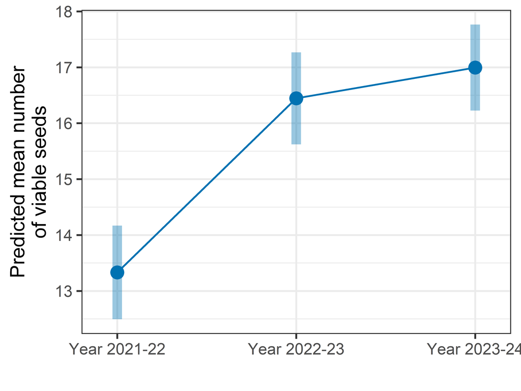

| contrast | estimate | t.ratio | p.value |
| --- | --- | --- | --- |
| (Year 2021-22) - (Year 2022-23) | -3.113 | -6.979 | 0.000 |
| (Year 2021-22) - (Year 2023-24) | -3.663 | -8.249 | 0.000 |
| (Year 2022-23) - (Year 2023-24) | -0.550 | -1.251 | 0.213 |

## Predictions with Type_of_farm

[figure not shown]

| Treatment | Boundary_type | Type_of_farm | Year | Predicted mean | lower.CL | upper.CL |
| --- | --- | --- | --- | --- | --- | --- |
| HP | Control farm | Cropping | Year 2021-22 | 16.4 | 11.1 | 21.7 |
| Open | Control farm | Cropping | Year 2021-22 | 10.6 | 5.3 | 15.9 |
| HP | Bare fence | Cropping | Year 2021-22 | 14.3 | 11.6 | 16.9 |
| Open | Bare fence | Cropping | Year 2021-22 | 9.4 | 6.8 | 12.1 |
| HP | New SNH | Cropping | Year 2021-22 | 17.0 | 13.9 | 20.0 |
| Open | New SNH | Cropping | Year 2021-22 | 12.7 | 9.6 | 15.7 |
| HP | Old SNH | Cropping | Year 2021-22 | 14.2 | 11.5 | 16.8 |
| Open | Old SNH | Cropping | Year 2021-22 | 12.6 | 10.0 | 15.3 |
| HP | Control farm | Dairy | Year 2021-22 | 14.6 | 12.6 | 16.6 |
| Open | Control farm | Dairy | Year 2021-22 | 9.1 | 7.1 | 11.1 |
| HP | Bare fence | Dairy | Year 2021-22 | 14.7 | 12.7 | 16.6 |
| Open | Bare fence | Dairy | Year 2021-22 | 10.4 | 8.4 | 12.4 |
| HP | New SNH | Dairy | Year 2021-22 | 16.5 | 13.4 | 19.5 |
| Open | New SNH | Dairy | Year 2021-22 | 12.0 | 8.9 | 15.0 |
| HP | Old SNH | Dairy | Year 2021-22 | 15.5 | 13.6 | 17.4 |
| Open | Old SNH | Dairy | Year 2021-22 | 13.5 | 11.7 | 15.4 |
| HP | Control farm | Cropping | Year 2022-23 | 19.2 | 13.9 | 24.5 |
| Open | Control farm | Cropping | Year 2022-23 | 13.2 | 7.9 | 18.5 |
| HP | Bare fence | Cropping | Year 2022-23 | 18.5 | 15.9 | 21.2 |
| Open | Bare fence | Cropping | Year 2022-23 | 12.8 | 10.2 | 15.5 |
| HP | New SNH | Cropping | Year 2022-23 | 16.1 | 13.5 | 18.7 |
| Open | New SNH | Cropping | Year 2022-23 | 17.3 | 14.7 | 19.9 |
| HP | Old SNH | Cropping | Year 2022-23 | 18.7 | 16.1 | 21.3 |
| Open | Old SNH | Cropping | Year 2022-23 | 17.7 | 15.0 | 20.3 |
| HP | Control farm | Dairy | Year 2022-23 | 18.0 | 16.0 | 19.9 |
| Open | Control farm | Dairy | Year 2022-23 | 11.9 | 9.9 | 13.9 |
| HP | Bare fence | Dairy | Year 2022-23 | 16.9 | 14.9 | 18.9 |
| Open | Bare fence | Dairy | Year 2022-23 | 12.7 | 10.7 | 14.7 |
| HP | New SNH | Dairy | Year 2022-23 | 16.0 | 12.9 | 19.0 |
| Open | New SNH | Dairy | Year 2022-23 | 17.0 | 14.0 | 20.1 |
| HP | Old SNH | Dairy | Year 2022-23 | 18.7 | 16.9 | 20.6 |
| Open | Old SNH | Dairy | Year 2022-23 | 18.4 | 16.5 | 20.3 |
| HP | Control farm | Cropping | Year 2023-24 | 18.4 | 15.7 | 21.0 |
| Open | Control farm | Cropping | Year 2023-24 | 15.2 | 12.6 | 17.9 |
| HP | Bare fence | Cropping | Year 2023-24 | 18.1 | 15.7 | 20.4 |
| Open | Bare fence | Cropping | Year 2023-24 | 13.3 | 10.9 | 15.7 |
| HP | New SNH | Cropping | Year 2023-24 | 18.9 | 16.2 | 21.5 |
| Open | New SNH | Cropping | Year 2023-24 | 17.1 | 14.5 | 19.7 |
| HP | Old SNH | Cropping | Year 2023-24 | 18.3 | 15.9 | 20.6 |
| Open | Old SNH | Cropping | Year 2023-24 | 16.7 | 14.3 | 19.0 |
| HP | Control farm | Dairy | Year 2023-24 | 17.7 | 15.0 | 20.3 |
| Open | Control farm | Dairy | Year 2023-24 | 11.2 | 8.6 | 13.9 |
| HP | Bare fence | Dairy | Year 2023-24 | 19.3 | 15.6 | 23.1 |
| Open | Bare fence | Dairy | Year 2023-24 | 14.4 | 10.7 | 18.1 |
| HP | New SNH | Dairy | Year 2023-24 | 20.8 | 17.7 | 23.8 |
| Open | New SNH | Dairy | Year 2023-24 | 17.4 | 14.4 | 20.5 |
| HP | Old SNH | Dairy | Year 2023-24 | 18.4 | 16.1 | 20.8 |
| Open | Old SNH | Dairy | Year 2023-24 | 16.8 | 14.5 | 19.2 |

| contrast | Boundary_type | Type_of_farm | Year | estimate | t.ratio | p.value |
| --- | --- | --- | --- | --- | --- | --- |
| HP - Open | Control farm | Cropping | Year 2021-22 | 5.767 | 1.822 | 0.071 |
| HP - Open | Bare fence | Cropping | Year 2021-22 | 4.833 | 3.054 | 0.003 |
| HP - Open | New SNH | Cropping | Year 2021-22 | 4.283 | 2.344 | 0.021 |
| HP - Open | Old SNH | Cropping | Year 2021-22 | 1.536 | 0.971 | 0.333 |
| HP - Open | Control farm | Dairy | Year 2021-22 | 5.489 | 4.588 | 0.000 |
| HP - Open | Bare fence | Dairy | Year 2021-22 | 4.279 | 3.577 | 0.000 |
| HP - Open | New SNH | Dairy | Year 2021-22 | 4.521 | 2.474 | 0.015 |
| HP - Open | Old SNH | Dairy | Year 2021-22 | 1.963 | 1.754 | 0.082 |
| HP - Open | Control farm | Cropping | Year 2022-23 | 5.944 | 1.878 | 0.063 |
| HP - Open | Bare fence | Cropping | Year 2022-23 | 5.710 | 3.608 | 0.000 |
| HP - Open | New SNH | Cropping | Year 2022-23 | -1.189 | -0.751 | 0.454 |
| HP - Open | Old SNH | Cropping | Year 2022-23 | 1.032 | 0.652 | 0.515 |
| HP - Open | Control farm | Dairy | Year 2022-23 | 6.068 | 5.072 | 0.000 |
| HP - Open | Bare fence | Dairy | Year 2022-23 | 4.251 | 3.554 | 0.001 |
| HP - Open | New SNH | Dairy | Year 2022-23 | -1.061 | -0.581 | 0.562 |
| HP - Open | Old SNH | Dairy | Year 2022-23 | 0.315 | 0.281 | 0.779 |
| HP - Open | Control farm | Cropping | Year 2023-24 | 3.167 | 2.002 | 0.047 |
| HP - Open | Bare fence | Cropping | Year 2023-24 | 4.763 | 3.365 | 0.001 |
| HP - Open | New SNH | Cropping | Year 2023-24 | 1.773 | 1.120 | 0.265 |
| HP - Open | Old SNH | Cropping | Year 2023-24 | 1.585 | 1.120 | 0.265 |
| HP - Open | Control farm | Dairy | Year 2023-24 | 6.456 | 4.079 | 0.000 |
| HP - Open | Bare fence | Dairy | Year 2023-24 | 4.934 | 2.205 | 0.029 |
| HP - Open | New SNH | Dairy | Year 2023-24 | 3.322 | 1.818 | 0.071 |
| HP - Open | Old SNH | Dairy | Year 2023-24 | 1.602 | 1.132 | 0.260 |

## Graph of data with model predictions

[figure not shown]